# Clase 1: Ejercicios

2026-06-30

Completa los chunks de código. Cuando termines, haz **Knit** y verifica que todo corra sin errores antes de entregar.

# Parte 1 — R básico

**Ejercicio 1.** Calcula lo siguiente. Intenta predecir el resultado antes de correr cada línea:

```r
# a) Raíz cuadrada de 225 más 3 elevado a la 4
(sqrt(225)+3)^4
```

```
## [1] 104976
```

```r
# b) Residuo de dividir 1000 entre 7 (operador %%)

1000%%7
```

```
## [1] 6
```

```r
# c) e elevado a la 2

exp(2)
```

```
## [1] 7.389056
```

**Ejercicio 2.** México tuvo en 2023 un PIB nominal de 29,700 miles de millones de pesos y un deflactor del PIB de 148.3 (base 2013 = 100). Guarda cada valor en un objeto con nombre descriptivo y calcula el PIB real.

```r
pib2023 <- 29.7 #miles de millones
deflactor <- 148.3 #año base 2013 = 100

pibReal2023 <- pib2023 / (deflactor/100)
(pibReal2023)
```

```
## [1] 20.02697
```

**Ejercicio 3.** Sin correr el código, escribe en un comentario si cada expresión devuelve `TRUE` o `FALSE`. Luego verifica:

```r
 10 == 10 #True
```

```
## [1] TRUE
```

```r
10 != 10 #False
```

```
## [1] FALSE
```

```r
 (5 > 3) & (8 < 5) #false
```

```
## [1] FALSE
```

```r
(5 > 3) | (8 < 5) #true
```

```
## [1] TRUE
```

```r
!(3 > 1) #False
```

```
## [1] FALSE
```

# Parte 2 — Tipos de datos y vectores

**Ejercicio 4.** Para cada objeto, escribe en un comentario qué tipo crees que es *antes* de verificarlo con `class()`. Al final explica por qué `d` no es numérico aunque parece serlo:

```r
a <- 19500.75
b <- "tasa de desempleo"
c <- FALSE
d <- "2.8"

# Tu código aquí
# a es numerico
#b es character
# c es logical
# d es character. Esta delimitado por comillas, se trata como texto.

a <- 19500.75
class(a)
```

```
## [1] "numeric"
```

```r
b <- "tasa de desempleo"
class(b)
```

```
## [1] "character"
```

```r
c <- FALSE
class(c)
```

```
## [1] "logical"
```

```r
d <- "2.8"
class(d)
```

```
## [1] "character"
```

**Ejercicio 5.** Tenemos datos de desempleo para 20 países de América Latina y el Caribe. Usa los datos generados para contestar las preguntas.

```r
set.seed(42)
paises <- c("México", "Brasil", "Argentina", "Colombia", "Chile", "Perú",
            "Venezuela", "Ecuador", "Bolivia", "Paraguay", "Uruguay",
            "Costa Rica", "Panamá", "Guatemala", "Honduras", "El Salvador",
            "Nicaragua", "Cuba", "República Dominicana", "Jamaica")

desempleo <- round(runif(n = 20, min = 2.0, max = 15.0), 1)
```

1. ¿Cuál es la tasa promedio del grupo?

```r
mean(desempleo)
```

```
## [1] 9.97
```

2. ¿Cuántos países tienen desempleo mayor al promedio? (pista: suma un vector lógico)

```r
sum(desempleo > mean(desempleo))
```

```
## [1] 11
```

3. ¿Qué países tienen desempleo menor a 7%?

```r
paises[desempleo < 7]
```

```
## [1] "Argentina" "Ecuador"   "Guatemala" "Cuba"
```

4. Crea un vector lógico llamado `alto_desempleo` que sea `TRUE` para países con desempleo mayor a 10%

```r
alto_desempleo <- desempleo > 10
alto_desempleo
```

```
##  [1]  TRUE  TRUE FALSE  TRUE  TRUE FALSE  TRUE FALSE  TRUE  TRUE FALSE  TRUE
## [13]  TRUE FALSE FALSE  TRUE  TRUE FALSE FALSE FALSE
```

# Parte 3 — Data frames

**Ejercicio 6.** Tenemos un panel de 30 países con tres variables macroeconómicas simuladas.

```r
set.seed(7)

n <- 30

paises_macro <- c("México", "Brasil", "Argentina", "Colombia", "Chile", "Perú",
                  "Venezuela", "Ecuador", "Bolivia", "Paraguay", "Uruguay",
                  "Costa Rica", "Panamá", "Guatemala", "Honduras", "El Salvador",
                  "Nicaragua", "Cuba", "Rep. Dominicana", "Jamaica",
                  "Trinidad y Tobago", "Bahamas", "Haití", "Belice", "Guyana",
                  "Surinam", "Barbados", "Santa Lucía", "Granada", "Dominica")

macro <- data.frame(
  pais      = paises_macro,
  pib       = round(runif(n, min = 50,   max = 2500), 1),  # miles de mill. USD
  inflacion = round(runif(n, min = 1.5,  max = 50.0), 1),  # %
  desempleo = round(runif(n, min = 2.0,  max = 18.0), 1)   # %
)
```

1. Muestra el resumen estadístico de la base de datos

```r
summary(macro)
```

```
##      pais                pib           inflacion       desempleo
##  Length:30          Min.   :  71.3   Min.   : 5.50   Min.   : 3.30
##  Class :character   1st Qu.: 507.4   1st Qu.:17.73   1st Qu.: 7.75
##  Mode  :character   Median :1092.7   Median :27.50   Median : 9.90
##                     Mean   :1239.8   Mean   :27.88   Mean   :10.22
##                     3rd Qu.:1978.7   3rd Qu.:39.60   3rd Qu.:12.95
##                     Max.   :2491.9   Max.   :48.40   Max.   :16.90
```

2. Agrega una columna `inflacion_alta` que sea `TRUE` si la inflación supera 10%

```r
macro$inflacion_alta <- macro$inflacion > 10
macro
```

```
##                 pais    pib inflacion desempleo inflacion_alta
## 1             México 2472.8      34.5       5.1           TRUE
## 2             Brasil 1024.5      14.3      10.1           TRUE
## 3          Argentina  333.5      10.5      14.2           TRUE
## 4           Colombia  220.9      10.5      13.1           TRUE
## 5              Chile  647.2      19.9      10.7           TRUE
## 6               Perú 1990.4      42.6      12.5           TRUE
## 7          Venezuela  883.2      25.7       9.5           TRUE
## 8            Ecuador 2431.6      39.8       9.7           TRUE
## 9            Bolivia  456.3      42.2       7.4           TRUE
## 10          Paraguay 1174.8      23.7       8.8           TRUE
## 11           Uruguay  470.8      40.3       6.6           TRUE
## 12        Costa Rica  617.1      20.0      11.6           TRUE
## 13            Panamá 1943.4      38.3      15.5           TRUE
## 14         Guatemala  285.9      22.7      11.9           TRUE
```

[output cut: 16 more lines]

3. Filtra solo los países con desempleo menor a 8% y guárdalos en un objeto llamado `desempleo_bajo`

```r
desempleo_bajo <- macro[macro$desempleo < 8, ]
desempleo_bajo
```

```
##        pais    pib inflacion desempleo inflacion_alta
## 1    México 2472.8      34.5       5.1           TRUE
## 9   Bolivia  456.3      42.2       7.4           TRUE
## 11  Uruguay  470.8      40.3       6.6           TRUE
## 15 Honduras 1160.9      45.4       4.2           TRUE
## 23    Haití 2491.9      39.0       5.9           TRUE
## 26  Surinam  210.8      20.3       3.3           TRUE
## 27 Barbados 1586.2       9.4       3.5          FALSE
## 29  Granada 2429.0      20.5       7.6           TRUE
```

4. ¿Cuántos países tienen simultáneamente inflación alta **y** desempleo menor a 8%? (pista: combina condiciones con `&`)

```r
sum(macro$inflacion > 10 & macro$desempleo < 8)
```

```
## [1] 7
```

# Parte 4 — Matrices

El estimador de Mínimos Cuadrados Ordinarios tiene la siguiente forma matricial:

$$\hat{\beta} =
(X'X)^{-1}X'y$$

Donde $X$ es la matriz de regresores (con una columna de unos para la constante) e $y$ es el vector de la variable dependiente.

Ya tenemos los datos, el gráfico, y la matriz $X$ construida. Tu trabajo es calcular $\hat{\beta}$ paso a paso:

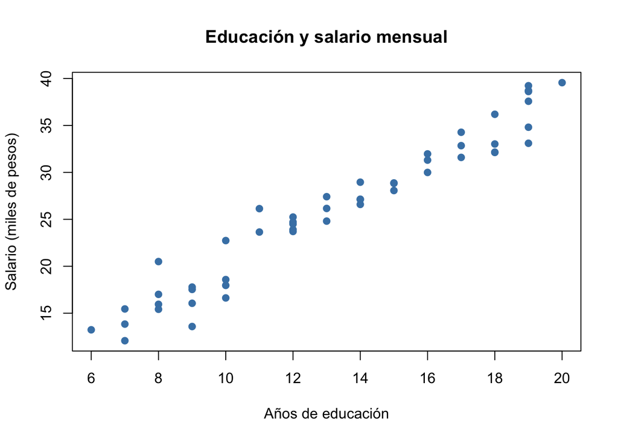

```r
set.seed(123)

n          <- 50
educacion  <- round(runif(n, min = 6, max = 20), 0)   # años de educación
error      <- rnorm(n, mean = 0, sd = 2)               # ruido aleatorio
salario    <- 2 + 1.8 * educacion + error              # miles de pesos al mes

# Gráfico ya hecho — obsérvalo antes de estimar
plot(educacion, salario,
     main = "Educación y salario mensual",
     xlab = "Años de educación",
     ylab = "Salario (miles de pesos)",
     pch  = 19, col = "steelblue")
```

```r
# Matriz X ya construida
X <- matrix(c(rep(1, n), educacion), nrow = n, ncol = 2)
colnames(X) <- c("constante", "educacion")

y <- matrix(salario, nrow = n)
```

**a)** Calcula $X'X$ y su inversa $(X'X)^{-1}$

```r
#X'X
XtX <- t(X) %*% X
XtX
```

```
##           constante educacion
## constante        50       662
## educacion       662      9588
```

```r
# (X'X)^-1
XtX_inv <- solve(XtX)
XtX_inv
```

```
##             constante   educacion
## constante  0.23296725 -0.01608514
## educacion -0.01608514  0.00121489
```

**b)** Calcula $X'y$

```r
Xty <- t(X) %*% y
Xty
```

```
##                [,1]
## constante  1297.219
## educacion 18702.212
```

**c)** Calcula $\hat{\beta} = (X'X)^{-1}X'y$

```r
beta_hat <- XtX_inv %*% Xty
beta_hat
```

```
##               [,1]
## constante 1.381827
## educacion 1.855178
```

# Parte 5 — ¿Qué está pasando aquí?

El siguiente script fue escrito a las 2am antes de una presentación. Funciona. Pero nadie sabe qué hace.

Tu tarea es dos cosas:

1. Reescríbelo con nombres descriptivos y formato legible
2. Explica en un comentario qué hace cada línea

```r
# 1. Configuración inicial y simulación de datos
set.seed(2026)  # Fija la semilla para que los números aleatorios sean siempre los mismos
total_equipos <- 32

# Definición de los 8 grupos del torneo
lista_grupos <- c("Grupo A", "Grupo B", "Grupo C", "Grupo D",
                  "Grupo E", "Grupo F", "Grupo G", "Grupo H")

# Creación del dataframe principal con los datos simulados de los equipos
datos_torneo <- data.frame(
  equipo    = paste0("Selección_", 1:total_equipos),   # Nombres: Selección_1 a Selección_32
  goles_favor  = round(runif(total_equipos, 0, 15)),   # Goles anotados aleatorios (entre 0 y 15)
  goles_contra = round(runif(total_equipos, 0, 15)),     # Goles recibidos aleatorios (entre 0 y 15)
  posicion_ranking = round(runif(total_equipos, 1, 32)), # Ranking aleatorio del equipo
  grupo     = rep(lista_grupos, each = 4)            # Asigna exactamente 4 equipos a cada grupo
)


# Calcula la diferencia de goles (Goles a Favor - Goles en Contra)
datos_torneo$diferencia_goles <- datos_torneo$goles_favor - datos_torneo$goles_contra

# Crea un indicador binario: 1 si la diferencia es positiva (ganador neto), 0 si es cero o negativa
datos_torneo$eficiencia_ganadora <- ifelse(datos_torneo$diferencia_goles > 0, 1, 0)



# Ordena todo el dataframe de manera descendente según los goles a favor
datos_ordenados <- datos_torneo[order(-datos_torneo$goles_favor), ]

# Selecciona únicamente los 8 equipos que más goles anotaron en el torneo
top_8_goleadores <- datos_ordenados[1:8, ]



# Calcula el promedio de goles a favor de estos 8 equipos de élite
promedio_goles_top8 <- mean(top_8_goleadores$goles_favor)

# Calcula la desviación estándar de los goles a favor de estos mismos 8 equipos
desviacion_goles_top8 <- sd(top_8_goleadores$goles_favor)

# Calcula el z-score para medir a cuántas desviaciones estándar del promedio está cada equipo del top 8
top_8_goleadores$z_score_goles <- (top_8_goleadores$goles_favor - promedio_goles_top8) / desviacion_goles_top8

#Impresión de resultados en consola
cat("Promedio de goles del Top 8:", round(promedio_goles_top8, 2), "\n")
```

```
## Promedio de goles del Top 8: 10.75
```

```r
cat("Top equipo:", top_8_goleadores$equipo[1], "con", top_8_goleadores$goles_favor[1], "goles\n")
```

```
## Top equipo: Selección_31 con 14 goles
```